### Data Analysis - Regression Tree & Random Forest models.

Fit a regression tree and plot it.

```r
library(tree)
set.seed(123456)
tree.train <- tree(classe~.,data=train.dat)
summary(tree.train)
```

```
##
## Classification tree:
## tree(formula = classe ~ ., data = train.dat)
## Variables actually used in tree construction:
##  [1] "pitch_forearm"     "magnet_belt_y"     "accel_forearm_z"
##  [4] "magnet_dumbbell_y" "roll_forearm"      "magnet_dumbbell_z"
##  [7] "accel_dumbbell_y"  "pitch_belt"        "yaw_belt"
## [10] "accel_forearm_x"   "yaw_dumbbell"      "magnet_forearm_y"
## [13] "magnet_arm_x"      "accel_dumbbell_z"
## Number of terminal nodes:  22
## Residual mean deviance:  1.602 = 18830 / 11750
## Misclassification error rate: 0.3112 = 3665 / 11776
```

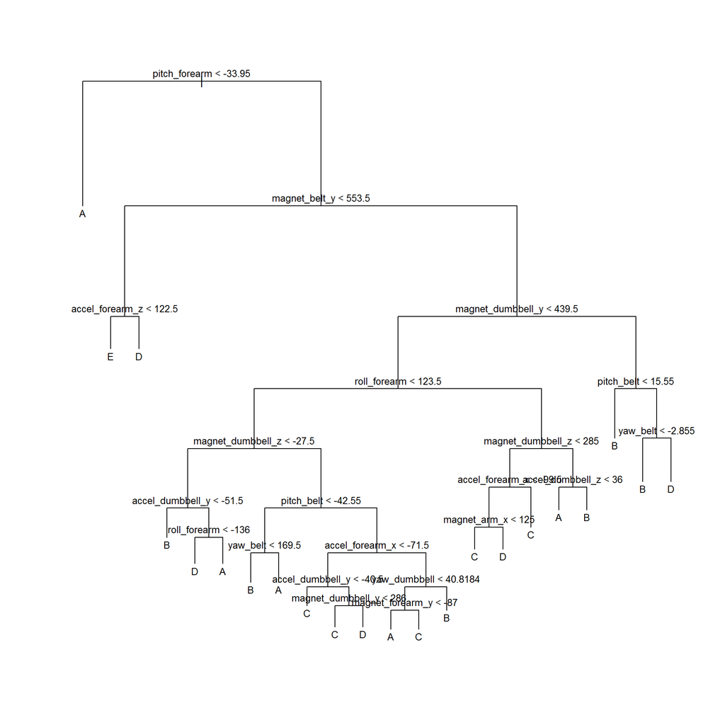

```r
plot(tree.train)
text(tree.train,pretty=0, cex =.8)
```

Cross validate the above tree with the testing data.

```r
tree.pred <- predict(tree.train,test.dat,type="class")
predMat <- with(test.dat,table(tree.pred,classe))
sum(diag(predMat))/sum(as.vector(predMat))
```

```
## [1] 0.6769054
```

The above tree probably has too much of variance. Hence the tree will be pruned using cross validation as detailed below.

```r
cv.train <- cv.tree(tree.train,FUN=prune.misclass)
cv.train
```

```
## $size
##  [1] 22 21 19 18 17 16 15 13 12 10  7  5  1
##
## $dev
##  [1] 3839 3875 3987 4136 4448 4707 4775 4824 5156 5435 5749 6193 8428
##
## $k
##  [1]     -Inf  60.0000  84.5000 107.0000 123.0000 132.0000 141.0000
##  [8] 145.0000 157.0000 170.0000 191.3333 223.5000 555.7500
##
## $method
## [1] "misclass"
##
## attr(,"class")
## [1] "prune"         "tree.sequence"
```

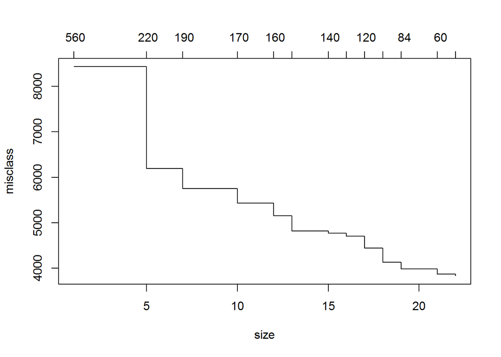

```r
plot(cv.train)
```

```r
prune.train <- prune.misclass(tree.train,best=15)

tree.pred <- predict(prune.train,test.dat,type="class")
predMat <- with(test.dat,table(tree.pred,classe))
sum(diag(predMat))/sum(as.vector(predMat))
```

```
## [1] 0.6176396
```

```r
require(randomForest)
set.seed(123456)
rf.train <- randomForest(classe~.,data=train.dat, ntree=100, importance=TRUE)
rf.train
```

```
##
## Call:
##  randomForest(formula = classe ~ ., data = train.dat, ntree = 100,      importance = TRUE)
##                Type of random forest: classification
##                      Number of trees: 100
## No. of variables tried at each split: 6
##
##         OOB estimate of  error rate: 0.94%
## Confusion matrix:
##      A    B    C    D    E class.error
## A 3344    4    0    0    0 0.001194743
## B   20 2245   13    0    1 0.014918824
## C    0   27 2021    6    0 0.016066212
## D    0    0   25 1901    4 0.015025907
## E    0    1    3    7 2154 0.005080831
```

The variables of high importance are shown in the plots below.

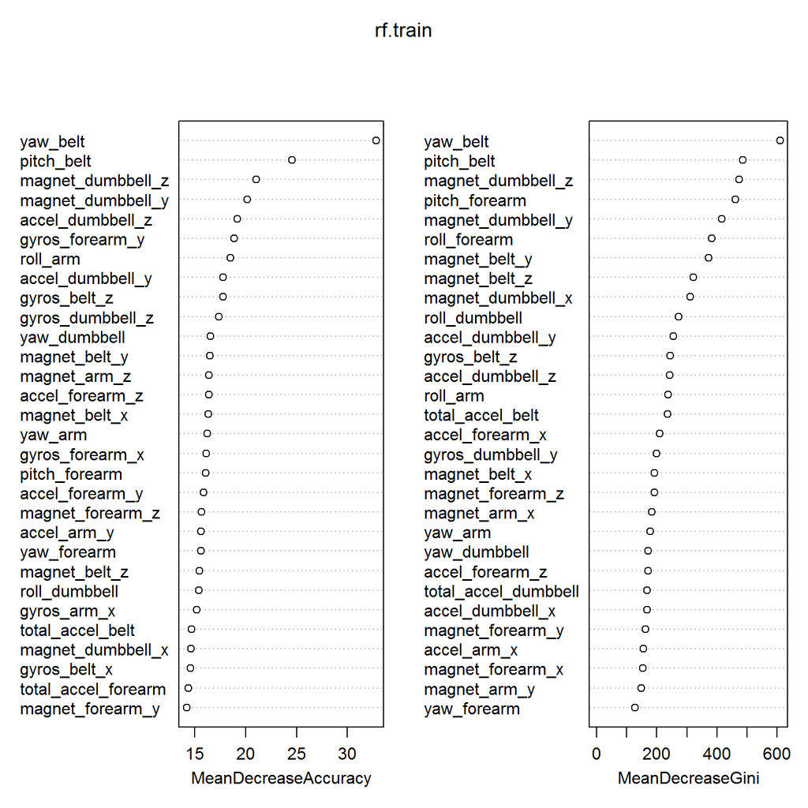

```r
varImpPlot(rf.train,)
```

Now we apply this random forest model on the test data and compute the out of sample accuracy.

```r
tree.pred <- predict(rf.train,test.dat,type="class")
predMat <- with(test.dat,table(tree.pred,classe))
sum(diag(predMat))/sum(as.vector(predMat))
```

```
## [1] 0.9922253
```

The above result shows that the random forest model is quite accurate. The predictions from this model were submitted online for the prediction assignment as illustrated below.

```r
answers <- predict(rf.train, testingDat)
answers
```

```
##  1  2  3  4  5  6  7  8  9 10 11 12 13 14 15 16 17 18 19 20
##  B  A  B  A  A  E  D  B  A  A  B  C  B  A  E  E  A  B  B  B
## Levels: A B C D E
```